# Laboratorio 1 Análisis Exploratorio

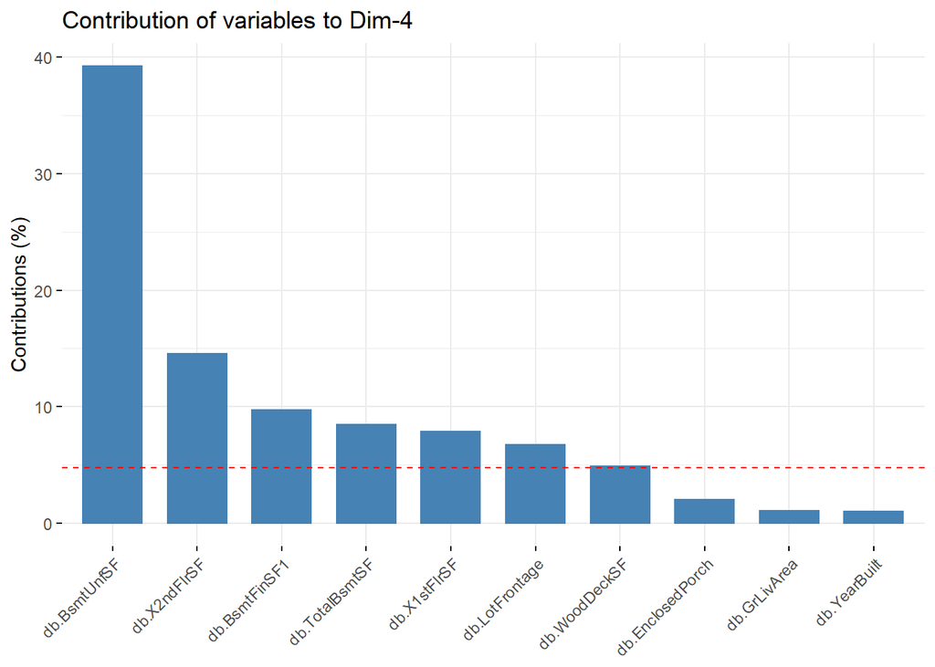

```r
fviz_contrib(compPrinc, choice = "var", axes = 4, top = 10) #Dimensión 4
```

Este componente puede represantarse como el tamano de las casas de 1 nivel.

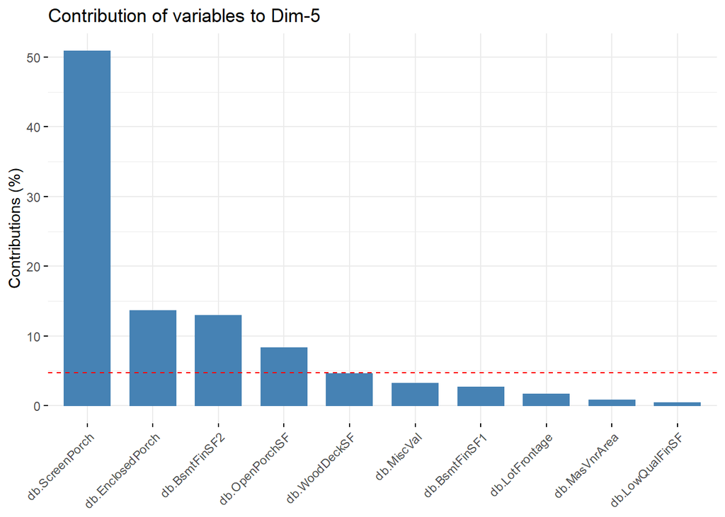

```r
fviz_contrib(compPrinc, choice = "var", axes = 5, top = 10) #Dimensión 5
```

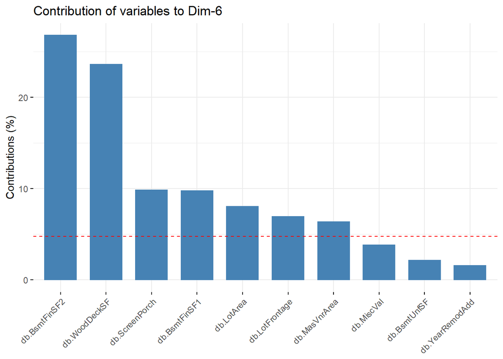

```r
fviz_contrib(compPrinc, choice = "var", axes = 6, top = 10) #Dimensión 6
```

Este componente abarca sobre el suelo de la propiedad.

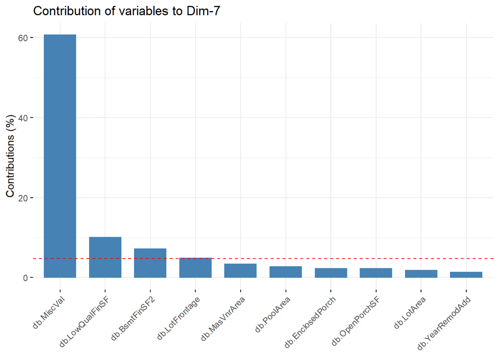

```r
fviz_contrib(compPrinc, choice = "var", axes = 7, top = 10) #Dimensión 7
```

El ultimo componente nos habla sobre los acabado que posee cada casa.

A continuacion veremos la representacion de cada variable en cada componente.

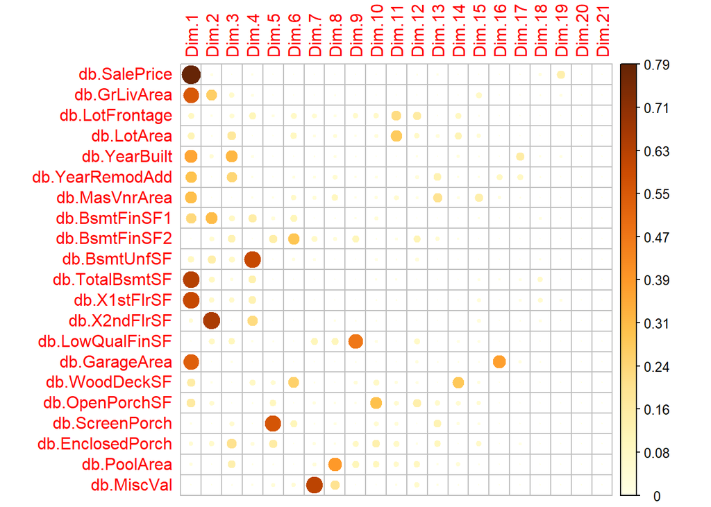

```r
var<-get_pca_var(compPrinc)
corrplot(var$cos2, is.corr = F)
```

## Reglas de asociacion

Se realizo las reglas de asociacion con una confianza de 0.7 y soporte de 0.2, donde se obtuvo lo siguiente:

```r
datos$db.LotFrontage[datos$db.LotFrontage==0] <- 63
datos$db.MasVnrArea[datos$db.MasVnrArea==0] <- 103.1
datos$db.BsmtFinSF1    [datos$db.BsmtFinSF1   ==0] <- 383.5
datos$db.BsmtFinSF2[datos$db.BsmtFinSF2==0] <- 46.55
datos$db.BsmtUnfSF[datos$db.BsmtUnfSF==0] <- 567.2



datos$db.SalePrice<-as.numeric(datos$db.SalePrice)
datos$db.GrLivArea<-as.factor(datos$db.GrLivArea)
datos$db.LotFrontage<-as.factor(datos$db.LotFrontage)
datos$db.LotArea<-as.factor(datos$db.LotArea)
datos$db.YearBuilt<-as.factor(datos$db.YearBuilt)
datos$db.YearRemodAdd<-as.factor(datos$db.YearRemodAdd)
datos$db.MasVnrArea<-as.factor(datos$db.MasVnrArea)
datos$db.BsmtFinSF1<-as.factor(datos$db.BsmtFinSF1)
datos$db.BsmtFinSF2<-as.factor(datos$db.BsmtFinSF2)
datos$db.BsmtUnfSF<-as.factor(datos$db.BsmtUnfSF)

datos$db.TotalBsmtSF<-as.factor(datos$db.TotalBsmtSF)
datos$db.X1stFlrSF<-as.factor(datos$db.X1stFlrSF)
datos$db.X2ndFlrSF<-as.factor(datos$db.X2ndFlrSF)
datos$db.LowQualFinSF<-as.factor(datos$db.LowQualFinSF)

datos$db.GarageArea<-as.factor(datos$db.GarageArea)
datos$db.WoodDeckSF<-as.factor(datos$db.WoodDeckSF)
datos$db.OpenPorchSF<-as.factor(datos$db.OpenPorchSF)
datos$db.ScreenPorch<-as.factor(datos$db.ScreenPorch)
datos$db.EnclosedPorch<-as.factor(datos$db.EnclosedPorch)
datos$db.PoolArea<-as.factor(datos$db.PoolArea)
datos$db.MiscVal<-as.factor(datos$db.MiscVal)

reglas<-apriori(datos[ ,2:16 ], parameter = list(support = 0.2,
                                                       confidence = 0.70,
                                                       target = "rules"))
```

```
## Apriori
##
## Parameter specification:
##  confidence minval smax arem  aval originalSupport maxtime support minlen
##         0.7    0.1    1 none FALSE            TRUE       5     0.2      1
##  maxlen target  ext
##      10  rules TRUE
##
## Algorithmic control:
##  filter tree heap memopt load sort verbose
##     0.1 TRUE TRUE  FALSE TRUE    2    TRUE
##
## Absolute minimum support count: 292
##
## set item appearances ...[0 item(s)] done [0.00s].
## set transactions ...[6464 item(s), 1460 transaction(s)] done [0.02s].
## sorting and recoding items ... [8 item(s)] done [0.00s].
## creating transaction tree ... done [0.00s].
## checking subsets of size 1 2 3 4 done [0.00s].
## writing ... [47 rule(s)] done [0.00s].
## creating S4 object  ... done [0.00s].
```

```r
inspect(reglas)
```

```
##      lhs                                   rhs                     support confidence  coverage      lift count
## [1]  {}                                 => {db.BsmtFinSF2=46.55} 0.8856164  0.8856164 1.0000000 1.0000000  1293
## [2]  {}                                 => {db.LowQualFinSF=0}   0.9821918  0.9821918 1.0000000 1.0000000  1434
## [3]  {db.BsmtFinSF1=383.5}              => {db.MasVnrArea=103.1} 0.2260274  0.7066381 0.3198630 1.1872171   330
## [4]  {db.BsmtFinSF1=383.5}              => {db.BsmtFinSF2=46.55} 0.3198630  1.0000000 0.3198630 1.1291570   467
## [5]  {db.BsmtFinSF1=383.5}              => {db.LowQualFinSF=0}   0.3102740  0.9700214 0.3198630 0.9876090   453
## [6]  {db.SalePrice=[1.4e+05,1.9e+05)}   => {db.BsmtFinSF2=46.55} 0.2835616  0.8679245 0.3267123 0.9800231   414
## [7]  {db.SalePrice=[1.4e+05,1.9e+05)}   => {db.LowQualFinSF=0}   0.3232877  0.9895178 0.3267123 1.0074589   472
## [8]  {db.SalePrice=[3.49e+04,1.4e+05)}  => {db.MasVnrArea=103.1} 0.2732877  0.8193018 0.3335616 1.3765025   399
## [9]  {db.SalePrice=[3.49e+04,1.4e+05)}  => {db.BsmtFinSF2=46.55} 0.2924658  0.8767967 0.3335616 0.9900411   427
## [10] {db.SalePrice=[3.49e+04,1.4e+05)}  => {db.LowQualFinSF=0}   0.3232877  0.9691992 0.3335616 0.9867718   472
## [11] {db.SalePrice=[1.9e+05,7.55e+05]}  => {db.BsmtFinSF2=46.55} 0.3095890  0.9112903 0.3397260 1.0289898   452
## [12] {db.SalePrice=[1.9e+05,7.55e+05]}  => {db.LowQualFinSF=0}   0.3356164  0.9879032 0.3397260 1.0058150   490
## [13] {db.X2ndFlrSF=0}                   => {db.BsmtFinSF2=46.55} 0.4863014  0.8564536 0.5678082 0.9670705   710
## [14] {db.X2ndFlrSF=0}                   => {db.LowQualFinSF=0}   0.5609589  0.9879373 0.5678082 1.0058497   819
## [15] {db.MasVnrArea=103.1}              => {db.BsmtFinSF2=46.55} 0.5191781  0.8722670 0.5952055 0.9849264   758
## [16] {db.MasVnrArea=103.1}              => {db.LowQualFinSF=0}   0.5773973  0.9700806 0.5952055 0.9876692   843
## [17] {db.BsmtFinSF2=46.55}              => {db.LowQualFinSF=0}   0.8698630  0.9822119 0.8856164 1.0000205  1270
## [18] {db.LowQualFinSF=0}                => {db.BsmtFinSF2=46.55} 0.8698630  0.8856346 0.9821918 1.0000205  1270
## [19] {db.MasVnrArea=103.1,
##       db.BsmtFinSF1=383.5}              => {db.BsmtFinSF2=46.55} 0.2260274  1.0000000 0.2260274 1.1291570   330
## [20] {db.BsmtFinSF1=383.5,
##       db.BsmtFinSF2=46.55}              => {db.MasVnrArea=103.1} 0.2260274  0.7066381 0.3198630 1.1872171   330
## [21] {db.MasVnrArea=103.1,
##       db.BsmtFinSF1=383.5}              => {db.LowQualFinSF=0}   0.2164384  0.9575758 0.2260274 0.9749377   316
## [22] {db.BsmtFinSF1=383.5,
##       db.BsmtFinSF2=46.55}              => {db.LowQualFinSF=0}   0.3102740  0.9700214 0.3198630 0.9876090   453
## [23] {db.BsmtFinSF1=383.5,
##       db.LowQualFinSF=0}                => {db.BsmtFinSF2=46.55} 0.3102740  1.0000000 0.3102740 1.1291570   453
## [24] {db.SalePrice=[1.4e+05,1.9e+05),
##       db.BsmtFinSF2=46.55}              => {db.LowQualFinSF=0}   0.2801370  0.9879227 0.2835616 1.0058348   409
## [25] {db.SalePrice=[1.4e+05,1.9e+05),
##       db.LowQualFinSF=0}                => {db.BsmtFinSF2=46.55} 0.2801370  0.8665254 0.3232877 0.9784432   409
## [26] {db.SalePrice=[3.49e+04,1.4e+05),
##       db.X2ndFlrSF=0}                   => {db.LowQualFinSF=0}   0.2116438  0.9686520 0.2184932 0.9862148   309
## [27] {db.SalePrice=[3.49e+04,1.4e+05),
##       db.MasVnrArea=103.1}              => {db.BsmtFinSF2=46.55} 0.2383562  0.8721805 0.2732877 0.9848287   348
## [28] {db.SalePrice=[3.49e+04,1.4e+05),
##       db.BsmtFinSF2=46.55}              => {db.MasVnrArea=103.1} 0.2383562  0.8149883 0.2924658 1.3692554   348
## [29] {db.SalePrice=[3.49e+04,1.4e+05),
```

[output cut: 29 more lines]

```
## [43] {db.SalePrice=[3.49e+04,1.4e+05),
##       db.MasVnrArea=103.1,
##       db.BsmtFinSF2=46.55}              => {db.LowQualFinSF=0}   0.2287671  0.9597701 0.2383562 0.9771718   334
## [44] {db.SalePrice=[3.49e+04,1.4e+05),
##       db.MasVnrArea=103.1,
##       db.LowQualFinSF=0}                => {db.BsmtFinSF2=46.55} 0.2287671  0.8697917 0.2630137 0.9821313   334
## [45] {db.SalePrice=[3.49e+04,1.4e+05),
##       db.BsmtFinSF2=46.55,
##       db.LowQualFinSF=0}                => {db.MasVnrArea=103.1} 0.2287671  0.8087167 0.2828767 1.3587185   334
## [46] {db.MasVnrArea=103.1,
##       db.BsmtFinSF2=46.55,
##       db.X2ndFlrSF=0}                   => {db.LowQualFinSF=0}   0.2616438  0.9769821 0.2678082 0.9946959   382
## [47] {db.MasVnrArea=103.1,
##       db.X2ndFlrSF=0,
##       db.LowQualFinSF=0}                => {db.BsmtFinSF2=46.55} 0.2616438  0.8268398 0.3164384 0.9336320   382
```

## Conclusiones

- Tras aplicar lo aprendido en clase, se logro obtener varios componentes, el cual cada uno demostro diferente categoria, tal como se comento anteriormente, esto facilitando la toma de datos de esta gran base de datos, obteniendo 7 componentes principales.
- La regla de asociacion nos permitio ver las relaciones que poseen cada elemento de la base de datos, datos que anteriormente no habiamos considerado, tal es el caso del precio de las casas con relacion a su tamano y no al acabado que tenia cada casa.
- El determinante de la matriz de correlación es muy relevante para determinar la existencia de multicolinealidad.
- La técnica de análisis de componentes principales es muy útil para reducir la dimensionalidad de un dataset.